# Guo | Speaking clearly improves speech segmentation by statistical learning under optimal listening conditions | Laboratory Phonology

## 3. Results

Responses in the test phase were analyzed. Failures to respond within the allotted time (i.e., five seconds) were recorded as time-outs and discarded. As in some artificial language learning studies (e.g., Frank, Goldwater, Griffiths, & Tenenbaum, 2010; Palmer & Mattys, 2016), participants whose accuracy rates were more than two standard deviations (*SD*s) below the mean of their condition were excluded as outliers. Four participants (2% of all participants: two from clear in quiet, one from conversational in quiet, and one from clear with noise at 0 dB SNR) were excluded. Figure 2 shows the accuracy rates of individual participants and the boxplots for two speaking styles and all listening conditions.

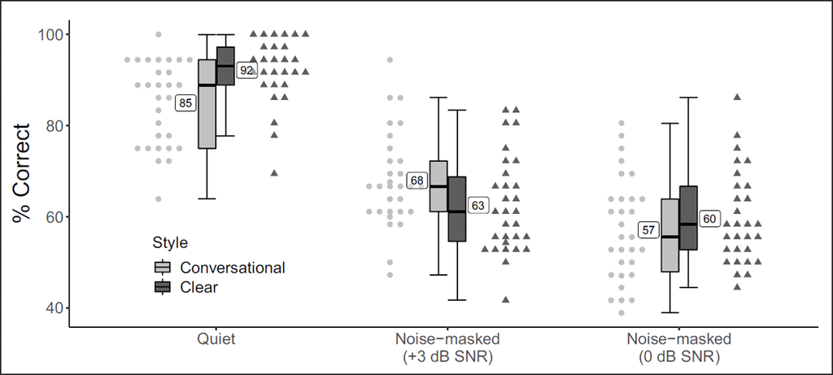

[Download](https://www.journal-labphon.org/article/id/6297/file/76068/)

Figure 2

Accuracy rates of individual participants with boxplots for two speaking styles and three listening conditions. The horizontal line in each box represents the median and the whiskers indicate the median ± 1.5 × interquartile range. The number beside each box represents the mean accuracy.

A Bayesian mixed-effects logistic regression model was fitted to the responses using the brms package (Bürkner, 2017) of R (R Core Team, 2020). We opted to use the Bayesian approach as it offers several advantages over traditional frequentist methods based on null-hypothesis significance testing (Kruschke, Aguinis, & Joo, 2012; Lee, 2011; Wagenmakers et al., 2018). For example, it allows the incorporation of prior knowledge in model estimation. Its output is a probability distribution of plausible parameter values, which has a natural interpretation like “There is 95% probability that the true parameter value falls between *x* and *y*, given the model and data.” As data are usually collected with the goal of obtaining insight about parameters, this is conceptually more appealing than point estimates like the *p*-value in frequentist analysis, which is the probability of the data given that the null hypothesis is true (see, inter alia, Kruschke, 2014, for more details about Bayesian methods and Vasishth, Nicenboim, Beckman, Li, & Kong, 2018, for a tutorial using brms). The data and script for the statistical analysis are available on the Open Science Framework (https://osf.io/9v7k4/).

The fixed effects of primary interest in our model were Style (baseline: conversational), Listening Condition (LisCond; baseline: quiet), and their interaction. In addition, following Ou and Guo (2021), we log-transformed and scaled response time (LogRT) and included it as a covariate to factor out any potential relationship between response latency and accuracy. The random effects were random intercepts for participant, word, and partword as well as by-word random slopes for all fixed factors and a by-partword random slope for Style. Since there were no previous attempts to investigate the impact of speaking style on statistical segmentation, we used weakly informative, regularizing priors that have a normal distribution with zero mean and *SD* of 10 on all fixed-effect coefficients. The *SD* parameters for the random effects had the same normal distribution except they included only positive values. As a standard option, we used the LKJ(2) prior (Lewandowski, Kurowicka, & Joe, 2009) on the correlation parameters between the random intercepts and slopes (Vasishth et al., 2018). The joint posterior distribution was sampled using four Markov chain Monte Carlo (MCMC) chains, each with 2,000 iterations and a warm-up of 1,000. The R-hat statistic (i.e., the ratio of between- to within-chain variance) was one for all parameters, indicating that the chains converged and could be representative of the underlying posterior distribution.

Figure 3 shows the marginal posteriors on all the fixed-effect parameters. A criterion for deciding whether a factor had a significant effect or whether two groups differ significantly in Bayesian inference is to examine the 95% credible interval (CI) of a posterior distribution—namely, the interval between the 2.5th and 97.5th percentiles of the distribution. Exclusion of zero from the interval is taken to be evidence for a significant effect or difference. For instance, the 95% CI was between –0.37 and –0.20 (mean: –0.29) for LogRT, meaning that given the model and data, there is a 95% probability that the parameter value of LogRT is between –0.37 and –0.20. The interval excluded zero and fell in the negative region, suggesting that there was an inverse relationship between response latency and accuracy: Responses with longer latencies were less likely to be correct. Such a relationship has been found in the artificial language learning experiments of Ou and Guo (2021). As they argue, this may reflect listeners’ response certainty or confidence. Recall that the two stimuli in each test trial were separated by a pause. Thus, listeners might be ready to respond as soon as they heard the first stimulus and could determine whether it was a word of the artificial language or a partword. But when they were indecisive, they might think longer and guess, resulting in slower and less accurate responses.

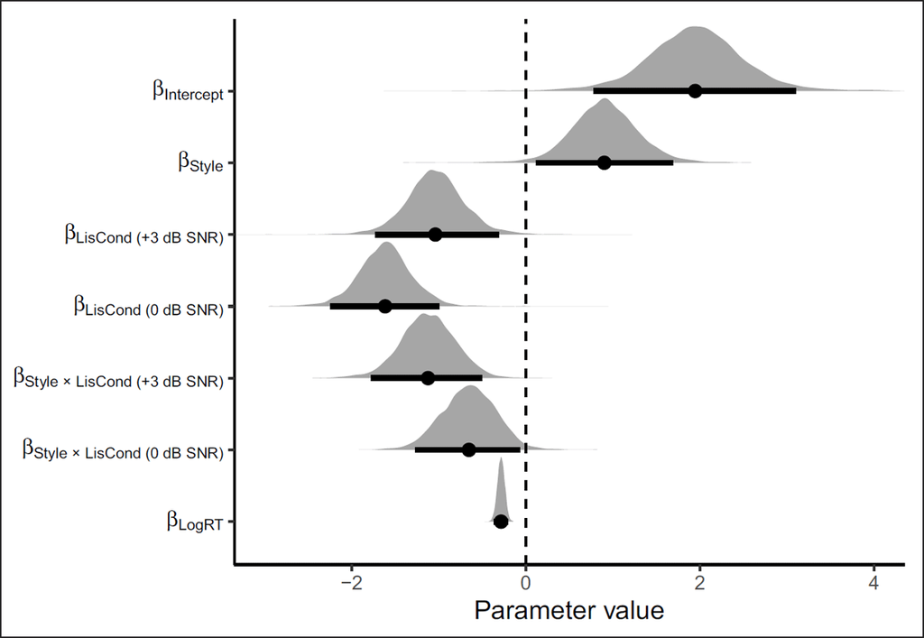

[Download](https://www.journal-labphon.org/article/id/6297/file/76069/)